# STAT510 Lesson 4 Application

Ada Lazuli

2026-06-14

## Front Matter

```r
library(astsa)
library(ggplot2)
library(reactable)
```

## Question 1

> Problem 3.37 of the book (p. 174) asks students to sketch the ACF of a seasonal ARIMA $(0,1)×(1,0)_{12}$ model with the non-seasonal MA $\theta_1 = 0.5$ and the seasonal AR $\Phi_1 = 0.8$. (They left out the differencing location, which means there is no differencing.)

> Here’s how you can do it in R:

> ```r
> acfprob1=ARMAacf(ar = c(0,0,0,0,0,0,0,0,0,0,0,.8), ma=c(.5),lag.max=61)
>
> plot(acfprob1, type="h")
> ```

> The first command asks for 61 lags. The ar list gives coefficients that are 0 up to the 12th lag where the coefficient = .8. The ma list gives the information that the first lag coefficient >= .5. In the plot command, the type = “h” causes projections from the value to the axis as we usually do in an ACF.

#### Part A.

> Use R to sketch the ACF in this situation. You may either type the plot command in R rather than copy and paste or you must paste as plain text. R doesn’t like Words’ quote marks. Give the ACF graph as the answer to this part.

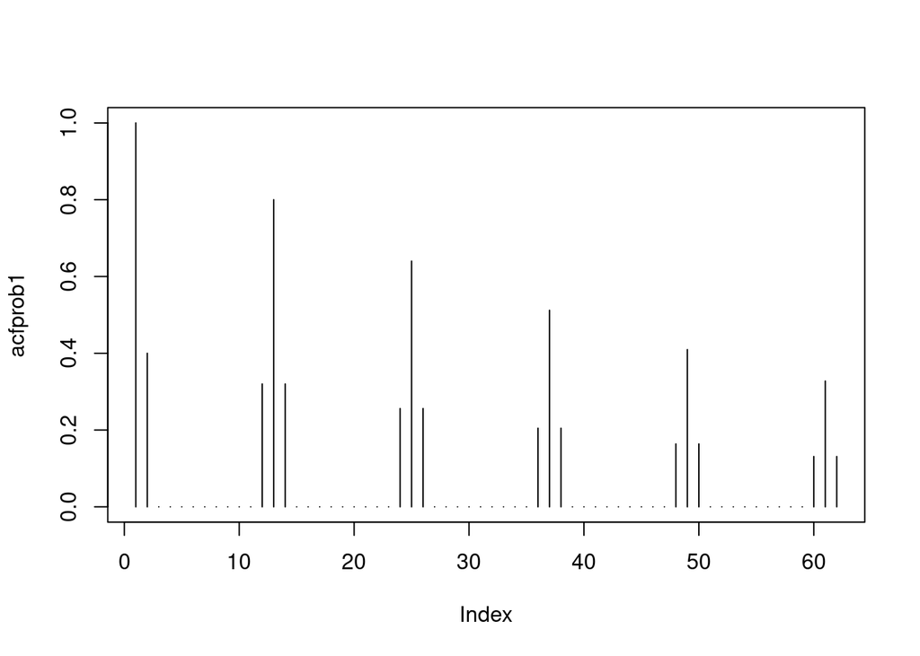

```r
acfprob1<-ARMAacf(ar = c(0,0,0,0,0,0,0,0,0,0,0,.8), ma=c(.5),lag.max=61)
plot(acfprob1, type="h")
```

#### Part B.

> To get the PACF of this model, modify the commands in the following way:

> ```r
> pacfprob1=ARMAacf(ar = c(0,0,0,0,0,0,0,0,0,0,0,.8), ma=c(.5),lag.max=61, pacf=TRUE)
> plot(pacfprob1, type="h")
> ```

> Use these commands to get the PACF of the model. Give the PACF as the answer to this problem.

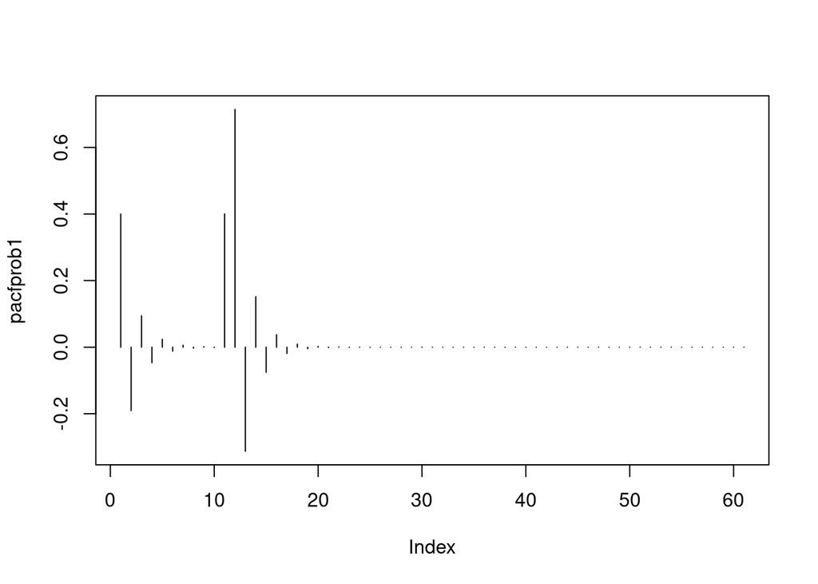

```r
pacfprob1<-ARMAacf(ar = c(0,0,0,0,0,0,0,0,0,0,0,.8), ma=c(.5),lag.max=61, pacf=TRUE)
plot(pacfprob1, type="h")
```

#### Part C.

> Write a brief description of the ACF and PACF patterns for this model.

The ACF shows a prominent spike at lag1 with prominent seasonal spikes along multiples of 12, with smaller spikes along each side that makes a trident shape. The PACF has significant spikes around the first seasonal spike near lag 12 and seems to drop off indefinately after lag 14.

#### Part D.

> Now consider the ARIMA $(1,0) \times (0,1)_{12}$ model with non-seasonal AR $\phi_1 = 0.8$ and seasonal MA $\Theta_1 = 0.5$ Graph hte ACF of this model.

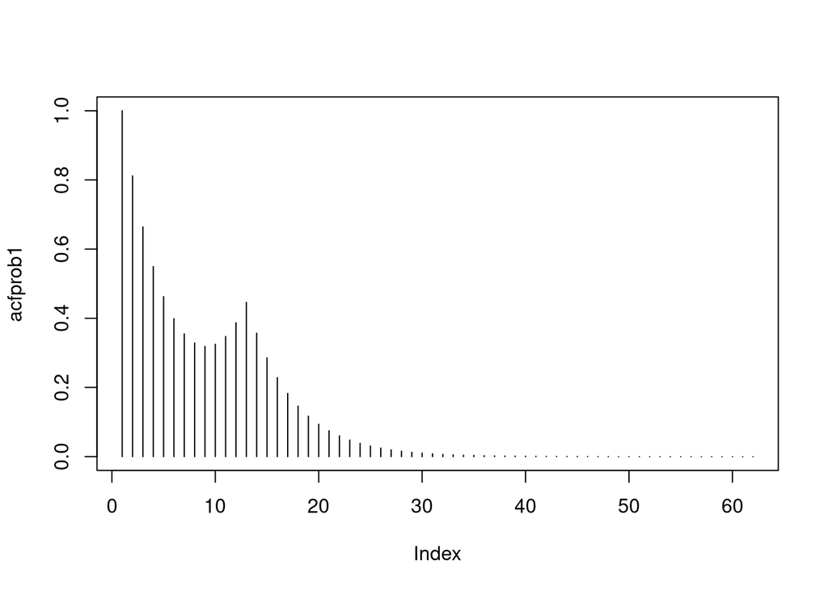

```r
acfprob1 <- ARMAacf(ar = 0.8, ma = c(rep(0, 11), 0.5), lag.max = 61)
plot(acfprob1, type="h")
```

#### Part E.

> Refer to part d. Graph the PACF for the model. Give the graph as the answer to this part.

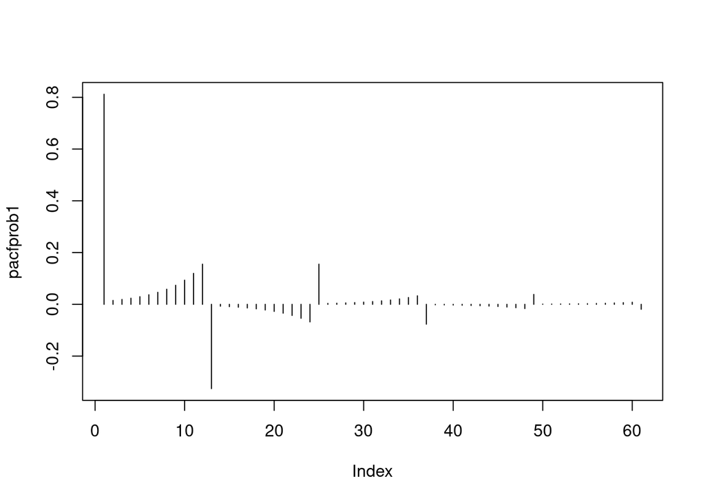

```r
pacfprob1 <- ARMAacf(ar = 0.8, ma = c(rep(0, 11), 0.5), lag.max = 61, pacf=TRUE)
plot(pacfprob1, type="h")
```

#### Part F.

> Write a brief description of the ACF and PACF patterns in parts d and e.

The ACF has significant spikes between lags 1 and 18, with a wave like crest at lag 12. After lag 18 the ACF trails off to 0. The PACF plot shows a significant offsetting seasonal trend on lags that are multiples of 12.

## Question 2

> This is a more structured version of problem 3.42 in the book (p. 174) that asks students to fit a model of their choice to the US Live Birth Series. It gives n = 373 consecutive monthly measures of the number of live births in the United States. The data are in the dataset birth.dat.

> Load the astsa library and read in the dataset:

> ```r
> library(astsa)
>
> birth=scan("birth.dat")
> ```

> Then, because we have linear trend and seasonality (monthly effects), apply both first and twelfth differences. Something like:

> ```r
> diff12 = diff(birth,12)
>
> acf2(diff12)
>
> diff1and12=diff(diff12,1)
> ```

```r
library(astsa)
birth<-scan("../sample_data/birth.dat")
diff12 <- diff(birth,12)
diff1and12 <-diff(diff12,1)
```

#### Part A.

> Use acf2 to determine the ACF and PACF of the differenced data. Be sure that you supply the differenced series (diff1and12) as a parameter of the acf2 command. Give the ACF and PACF of the differenced data.

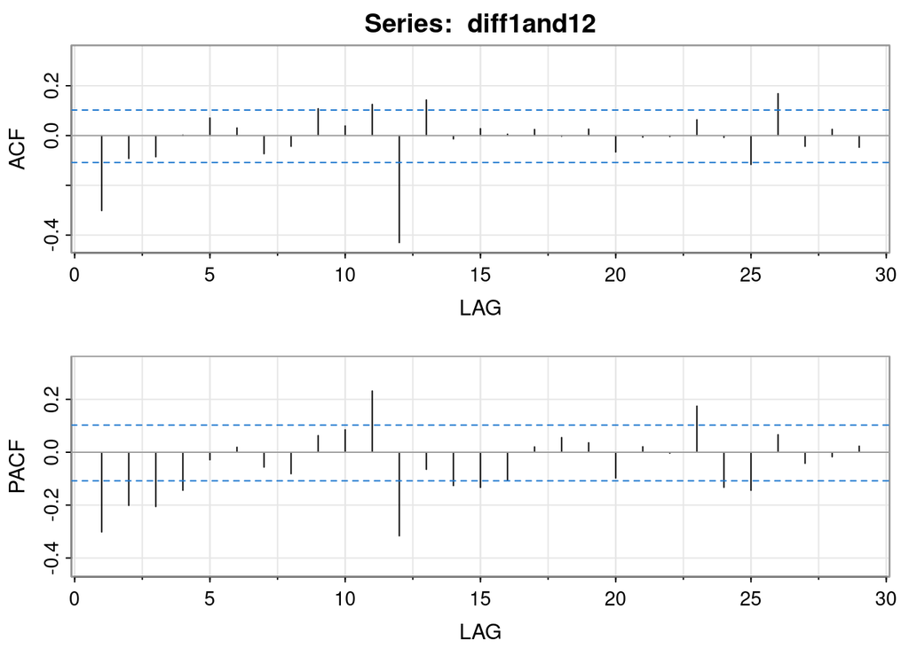

```
##      [,1]  [,2]  [,3]  [,4]  [,5] [,6]  [,7]  [,8] [,9] [,10] [,11] [,12] [,13]
## ACF  -0.3 -0.09 -0.09  0.00  0.07 0.03 -0.07 -0.04 0.11  0.04  0.13 -0.43  0.14
## PACF -0.3 -0.20 -0.21 -0.14 -0.03 0.02 -0.06 -0.08 0.06  0.08  0.23 -0.32 -0.06
##      [,14] [,15] [,16] [,17] [,18] [,19] [,20] [,21] [,22] [,23] [,24] [,25]
## ACF  -0.01  0.03  0.01  0.02  0.00  0.03 -0.07 -0.01     0  0.06 -0.01 -0.12
## PACF -0.13 -0.13 -0.11  0.02  0.06  0.04 -0.10  0.02     0  0.17 -0.13 -0.14
##      [,26] [,27] [,28] [,29]
## ACF   0.17 -0.04  0.03 -0.05
## PACF  0.07 -0.04 -0.02  0.02
```

```r
acf2(diff1and12)
```

#### Part B.

> Consider the ACF and PACF values for the first two or three lags. Explain why they suggest either an MA(1) or AR(1) as a possible non-seasonal component.

#### Part C.

> Examine the ACF and PACF at lags 12, 24 and 36. What possibilities are suggested for a seasonal component of the model? Provide reasoning.

The PACF shows seasonality more consistently than the ACF plot, which suggests there might be a seasonal autogregressive component to the time series.

#### Part D.

> The ACF and PACF don’t actually give a clear pointer to the best model in this case, but here some possibilities (Note that this list is not all-inclusive):

> $$ARIMA(0,1,1) \times (0,1,1)_{12} \\
> ARIMA(0,1,2) \times (0,1,1)_{12} \\
> ARIMA(1,1,1) \times (0,1,1)_{12} \\$$

> Assuming that you loaded the astsa library, the sarima command will estimate the first model above. `` r` sarima ( name of series, 0,1,1,0,1,1,12) ``

> Making necessary adjustments to the sarima command, estimate the three models above. For each give the variance estimate, information criterion, and a brief description of the model diagnostics. (You don’t have to provide all of the graphs.)

$ARIMA(0,1,1) \times (0,1,1)_{12}$

```
## <><><><><><><><><><><><><><>
##
## Coefficients:
##      Estimate     SE  t.value p.value
## ma1   -0.4734 0.0598  -7.9097       0
## sma1  -0.7861 0.0451 -17.4227       0
##
## sigma^2 estimated as 47.40199 on 358 degrees of freedom
##
## AIC = 6.74599  AICc = 6.746084  BIC = 6.778375
##
```

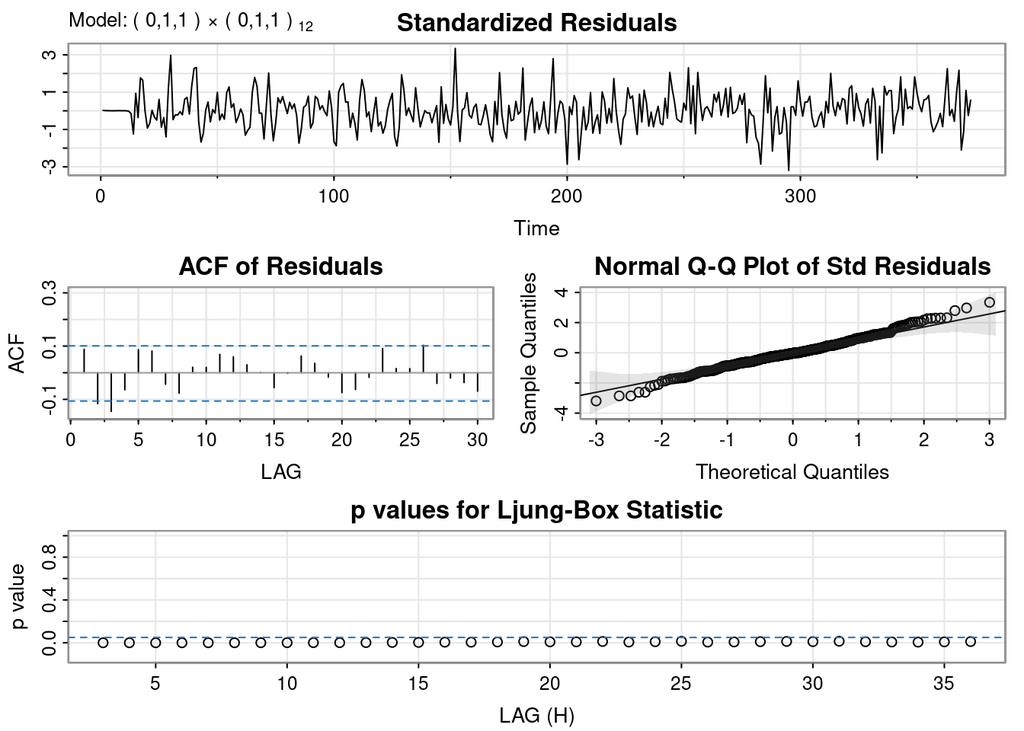

```r
sarima(birth, 0, 1, 1, 0, 1, 1, 12)
```

The ACF plot for the $ARIMA(0,1,1) \times (0,1,1)_{12}$ model has a two weakly significant spikes and the majority of the lags in the Ljung-Box plot have p-values less than 0.05. Overall, this is not an acceptable model.

$ARIMA(0,1,2) \times (0,1,1)_{12}$

```
## <><><><><><><><><><><><><><>
##
## Coefficients:
##      Estimate     SE  t.value p.value
## ma1   -0.3977 0.0514  -7.7433   0.000
## ma2   -0.1604 0.0484  -3.3112   0.001
## sma1  -0.7963 0.0443 -17.9808   0.000
##
## sigma^2 estimated as 45.94248 on 357 degrees of freedom
##
## AIC = 6.721871  AICc = 6.722058  BIC = 6.76505
##
```

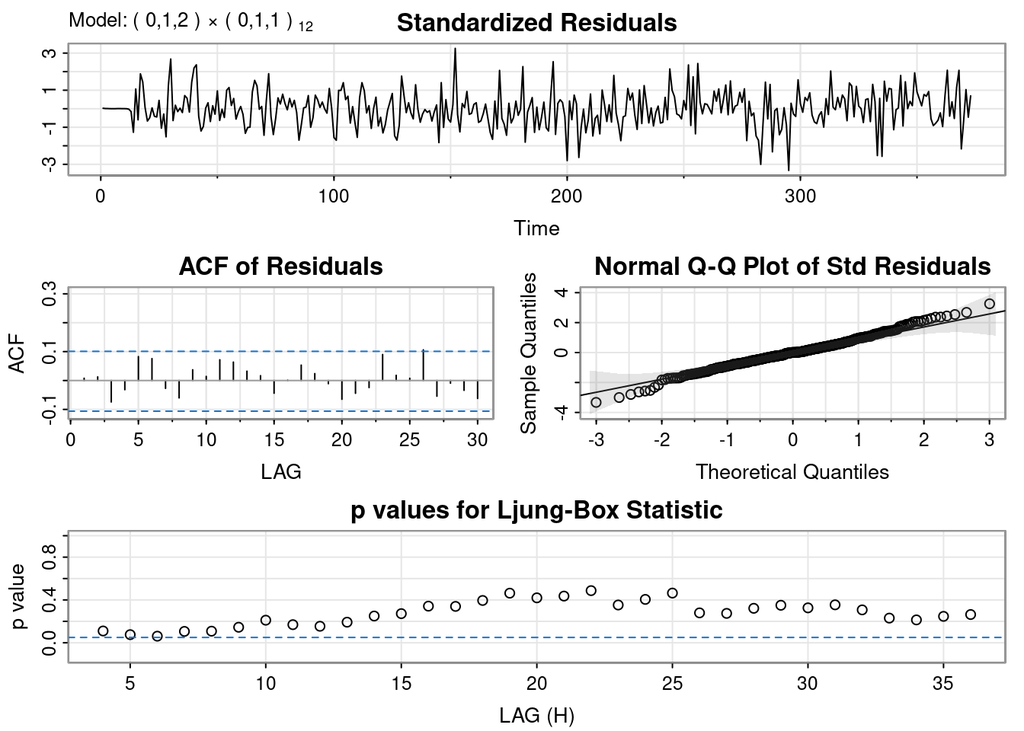

```r
sarima(birth, 0, 1, 2, 0, 1, 1, 12)
```

The diagnostic plots for the $ARIMA(0,1,2) \times (0,1,1)_{12}$ indicate that model is viable. None of the ACF spikes are significant, the residuals in the QQ plot seem to follow a normal distribution, and the vast majority of p-values are greater than 0.05 for the Ljung-Box statistic.

$ARIMA(1,1,1) \times (0,1,1)_{12}$

```
## <><><><><><><><><><><><><><>
##
## Coefficients:
##      Estimate     SE  t.value p.value
## ar1    0.3038 0.0865   3.5104   5e-04
## ma1   -0.7006 0.0604 -11.5984   0e+00
## sma1  -0.8000 0.0441 -18.1302   0e+00
##
## sigma^2 estimated as 45.91462 on 357 degrees of freedom
##
## AIC = 6.721818  AICc = 6.722006  BIC = 6.764997
##
```

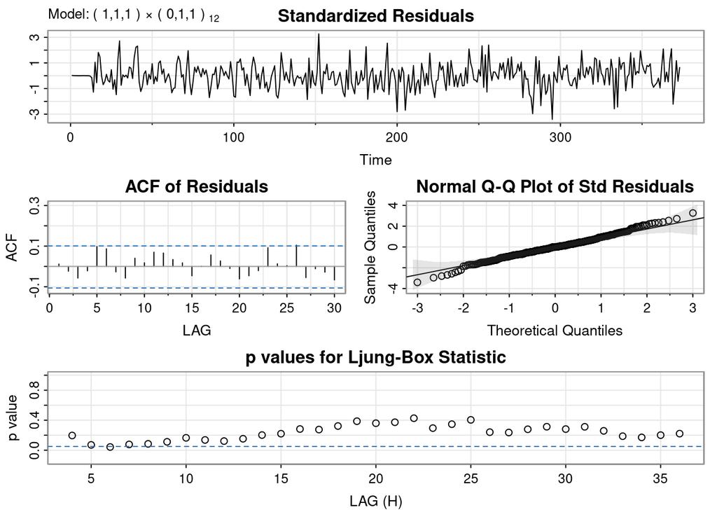

```r
sarima(birth, 1, 1, 1, 0, 1, 1, 12)
```

Similarly diagnostic plots for the $ARIMA(1,1,1) \times (0,1,1)_{12}$ indicate that model is viable. None of the ACF spikes are significant, the residuals in the QQ plot seem to follow a normal distribution, and the vast majority of p-values are greater than 0.05 for the Ljung-Box statistic.

#### Part E.

> Which of the three models in part d do you think is the best model? Explain.

The $ARIMA(1,1,1) \times (0,1,1)_{12}$ is the best choice because it has the lowest AIC value of $6.721818$ and BIC of $6.764997$.

## Question 3

> Determine a model for a monthly series. There are n = 200 data values. The data are in the file un2004.dat. In the TS plot, we can see an downward trend and seasonality with constant variance and no outliers.

#### Part A.

> Calculate a variable that is the result of applying a 12th difference and then confirm that a 1st difference is also necessary. Something like the following should do the trick:

> ```r
> diff12=diff(x,12)
> acf2(diff12)
> diff1and12=diff(diff12,1)
> ```

> Then determine the ACF and PACF of the differenced data series (diff1and12). Be sure to use the differenced series, not the original data for this step.

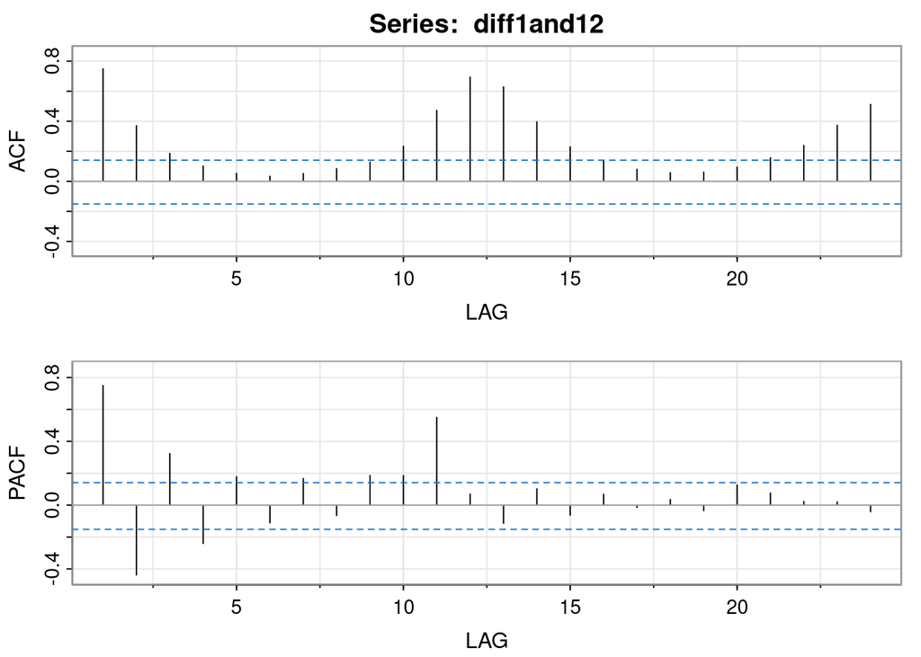

```
##      [,1]  [,2] [,3]  [,4] [,5]  [,6] [,7]  [,8] [,9] [,10] [,11] [,12] [,13]
## ACF  0.75  0.37 0.19  0.10 0.05  0.03 0.05  0.08 0.13  0.23  0.47  0.69  0.63
## PACF 0.75 -0.44 0.32 -0.24 0.18 -0.11 0.17 -0.06 0.19  0.19  0.55  0.07 -0.11
##      [,14] [,15] [,16] [,17] [,18] [,19] [,20] [,21] [,22] [,23] [,24]
## ACF    0.4  0.23  0.14  0.08  0.06  0.06  0.09  0.16  0.24  0.37  0.51
## PACF   0.1 -0.06  0.07 -0.01  0.03 -0.03  0.13  0.08  0.02  0.02 -0.04
```

```r
x <- ts(scan("../sample_data/un2004.dat"))
diff12 <- diff(x,12)
diff1and12 <- diff(diff12,1)
acf2(diff1and12)
```

**Part A.i**

> Discuss why the ACF and PACF suggest that an ARMA(1,1) may be good for the non-seasonal component. (Look at what’s happening for the first few lags in the ACF and PACF.)

The ACF and the PACF plots trail off and suggest that both AR(1) and MA(1) components are present.

**Part A.ii**

> Discuss why the ACF and PACF suggest that a seasonal AR(1) may be good for the seasonal component. Look at what’s happening around lags 12, 24, and so on.

An AR(1) is a better candidate as a seasonal component because of the ACF plot only trails off at lags 1, 12, and 24 (by extrapolating) while the PACF plot has a sharp cutoff after lag 12.

#### Part B.

> Fit an $ARIMA(1,1,1) \times (1,1,0)_{12}$ model to the original series. In the sarima command, specify the original series, not the differenced series because the differencing will be specified in the command itself. Discuss whether the diagnostics for the model suggest that the model is suitable. (Look at ACF of residuals, Ljung-Box-Pierce tests, and so on.)

```
## <><><><><><><><><><><><><><>
##
## Coefficients:
##      Estimate     SE t.value p.value
## ar1    0.3832 0.0743  5.1585       0
## ma1    0.8635 0.0400 21.5684       0
## sar1   0.6042 0.0581 10.3931       0
##
## sigma^2 estimated as 0.0006036802 on 184 degrees of freedom
##
## AIC = -4.492612  AICc = -4.491911  BIC = -4.423498
##
```

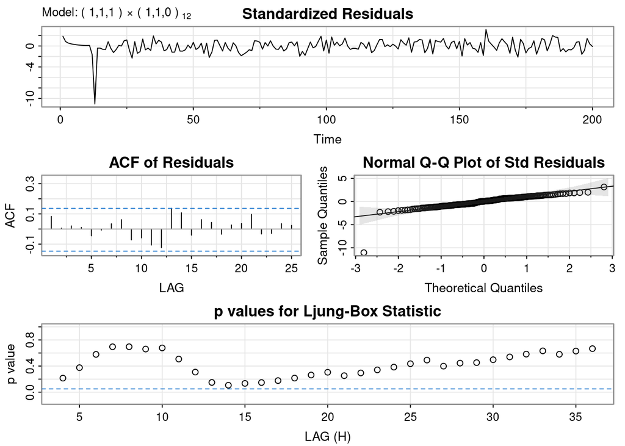

```r
sarima(x, 1, 1, 1, 1, 1, 0, 12)
```

#### Part C.

> Use the model fit in part b to forecast the values for the next 12 months following the end of the series. One possible command structure is

> ```r
> sarima.for (name of data series, 12, 1,1,1,1,1,0,12)
> ```

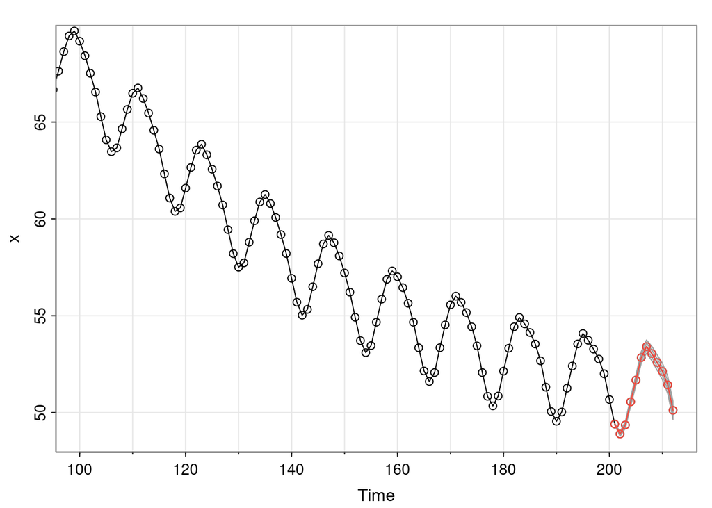

```
## $pred
## Time Series:
## Start = 201
## End = 212
## Frequency = 1
##  [1] 49.40459 48.89326 49.35893 50.55410 51.67464 52.83740 53.40705 53.04887
##  [9] 52.58479 52.12432 51.42710 50.11615
##
## $se
## Time Series:
## Start = 201
## End = 212
## Frequency = 1
##  [1] 0.02456990 0.06042171 0.09017449 0.11504095 0.13633263 0.15503486
##  [7] 0.17182099 0.18714559 0.20132065 0.21456619 0.22704207 0.23886788
```

```r
sarima.for (x, 12, 1,1,1,1,1,0,12)
```